# Build and annotate Human Cell Atlas Ontology immune graph

## Simplifying HCAO immune graph

We check the overall shape of the HCAO immune graph and how references mapped to it.

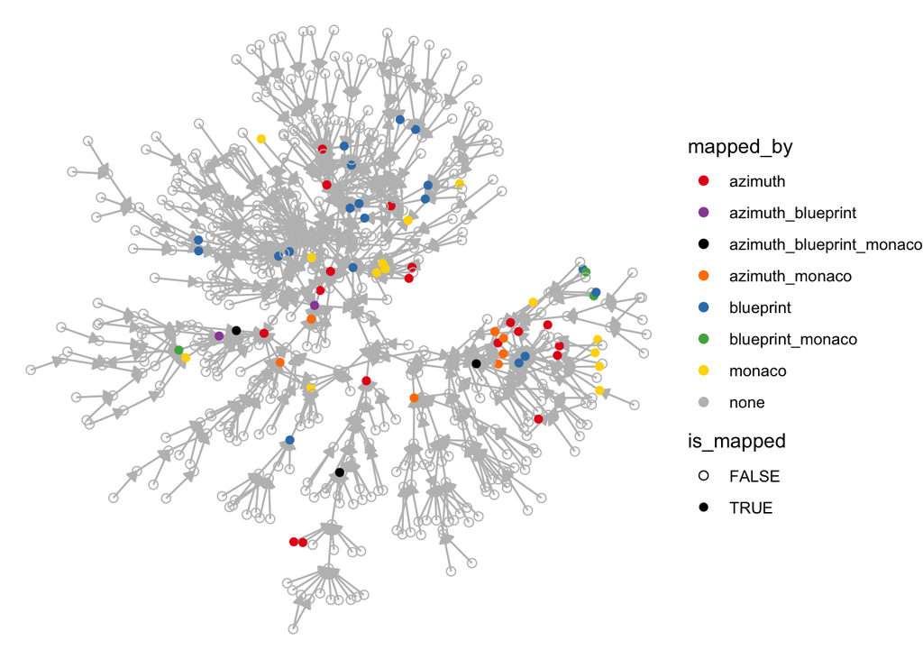

```r
# check mapped vertices by the 3 references
V(hcao.dag)$azimuth_mapped = V(hcao.dag)$name %in% azimuth_label_fine_to_ont$to
V(hcao.dag)$blueprint_mapped = V(hcao.dag)$name %in% blueprint_label_fine_to_ont$to
V(hcao.dag)$monaco_mapped = V(hcao.dag)$name %in% monaco_label_fine_to_ont$to
V(hcao.dag)$mapped_by = mapply(
  FUN=function(...){
    txt = paste0(c("azimuth","blueprint","monaco")[c(...)],collapse="_")
    if(nchar(txt)<=0) txt = "none"
    return(txt)
    },
  V(hcao.dag)$azimuth_mapped,V(hcao.dag)$blueprint_mapped,V(hcao.dag)$monaco_mapped)
V(hcao.dag)$is_mapped = mapply(
  any,
  V(hcao.dag)$azimuth_mapped,V(hcao.dag)$blueprint_mapped,V(hcao.dag)$monaco_mapped)

# mapping color/shape scheme
mapped_color = c(
  "azimuth" = "#e41a1c",
  "blueprint" = "#377eb8",
  "monaco" = "#FFD700",
  "azimuth_blueprint" = "#984ea3",
  "azimuth_monaco" = "#ff7f00",
  "blueprint_monaco" = "#4daf4a",
  "azimuth_blueprint_monaco" = "black",
  "none" = "grey"
)
mapped_shape = c("TRUE"=16,"FALSE"=1)

# visualization of the mapped DAG
hcao.dag.plot = ggraph(hcao.dag,layout = "kk")+
  geom_edge_link(arrow = arrow(length = unit(2, 'mm'),type = "closed"),color="grey") +
  geom_node_point(mapping = aes(color=mapped_by,shape=is_mapped),size=2) +
  scale_color_manual(values = mapped_color)+
  scale_shape_manual(values = mapped_shape)+
  theme_void()
print(hcao.dag.plot)
```

The full HCAO immune graph is messy and the references have not currently reached the bottom vertices. As a result, we need to simplify the HCAO immune graph for practical use of it. Briefly, for each mapped vertex we select the path to the root that goes through the most mapped vertices and aggregate them as the simplified HCAO immune graph, with a few exceptions for inclusion/exclusion based on manual curation of the outcome.

```r
### Refine tree to mostly azimuth/blueprint/monaco mapped vertices and resolve multi-parent issues
# also generate the dictionary of cellxgene CL labels to vertices in HCAO DAG

# get all paths to the root
all_paths_to_root = lapply(V(hcao.dag)$name,function(v){
  lapply(all_simple_paths(graph = hcao.dag,from = v,to = "CL_0000988"),as_ids)
})
names(all_paths_to_root) = V(hcao.dag)$name

# preferred vertices to keep in the DAG from manual curation
preferred_vertices = c(
  "CL_0000814", # natural killer T-cell that is not mapped by any reference
  "CL_0000097"  # mast cell that is not mapped by any reference
  )

# Vertices that should be avoided unless they are the only vertices leading to mapped ones
avoided_vertices = c(
  "CL_0000145", # professional antigen presenting cell
  "CL_1001610", # bone marrow hematopoietic cell
  "CL_0000081"  # blood cell that is synonymous to leukocyte
)

# which vertices are mapped by at least one reference
mapped_vertices = V(hcao.dag)$name[V(hcao.dag)$is_mapped]

# calculate the minimal required vertices for the DAG without multiple parent
minimal_edges = unique(do.call(
  rbind,lapply(c(mapped_vertices,preferred_vertices),function(x){
    these_paths = all_paths_to_root[[x]]
    should_avoid = sapply(these_paths,function(xx){any(xx%in%avoided_vertices)})
    if(sum(!should_avoid)>0) these_paths = these_paths[!should_avoid]
    path_lengths = sapply(these_paths,length)
    path_mapped_length = sapply(these_paths,function(xx){
      sum(xx%in%mapped_vertices)
    })
    path_unmapped_length = path_lengths - path_mapped_length
    minimum_length = min(path_lengths)
    max_mapped_length = max(path_mapped_length)
    min_unmapped_length = min(path_unmapped_length)
    ###  adjustable criteria
    candidate_paths = these_paths[path_mapped_length>=max_mapped_length]
    secondary_checked_length = sapply(candidate_paths,length)
    kept_path = candidate_paths[[which.min(secondary_checked_length)]]
    ###
    df = data.frame(
      from = kept_path[-length(kept_path)],
      to = kept_path[-1]
    )
    return(df)
  })
))
minimal_vertices = unique(c(minimal_edges$from,minimal_edges$to))

# add exception of non-immune cells to metadata
hcao_cl_metadata.df = data.frame(name=c("not hematopoietic",minimal_vertices))

# build simplified DAG
hcao.simplified.dag = graph_from_data_frame(
  d = minimal_edges,
  vertices = hcao_cl_metadata.df,
  directed = TRUE)
```

From the simplified HCAO immune graph, we build the dictionary between the original CELLxGENE annotation and HCAO immune graph.

```r
# build cellxgene to HCAO dictionary
cellxgene_CL_to_ont = data.frame(
  from=V(hcao.dag)$name,
  to=sapply(V(hcao.dag)$name,function(x){
    if(x%in%minimal_vertices) return(x)
    these_paths = all_paths_to_root[[x]]
    nearest_vertex_idx = which.min(
      sapply(these_paths,function(xx){
        min(which(xx%in%minimal_vertices))-1
        }))
    y = these_paths[[nearest_vertex_idx]][these_paths[[nearest_vertex_idx]]%in%minimal_vertices]
    return(y[1])
  }),
  is_immune=TRUE)

write.table(cellxgene_CL_to_ont,file = "immune_map_cellxgene_to_CL.csv",
            quote = FALSE,row.names = FALSE,col.names = TRUE,sep=",")
```

## QC of HCAO immune graph

We check the HCAO immune graph visually to make sure it makes the best biological sense.

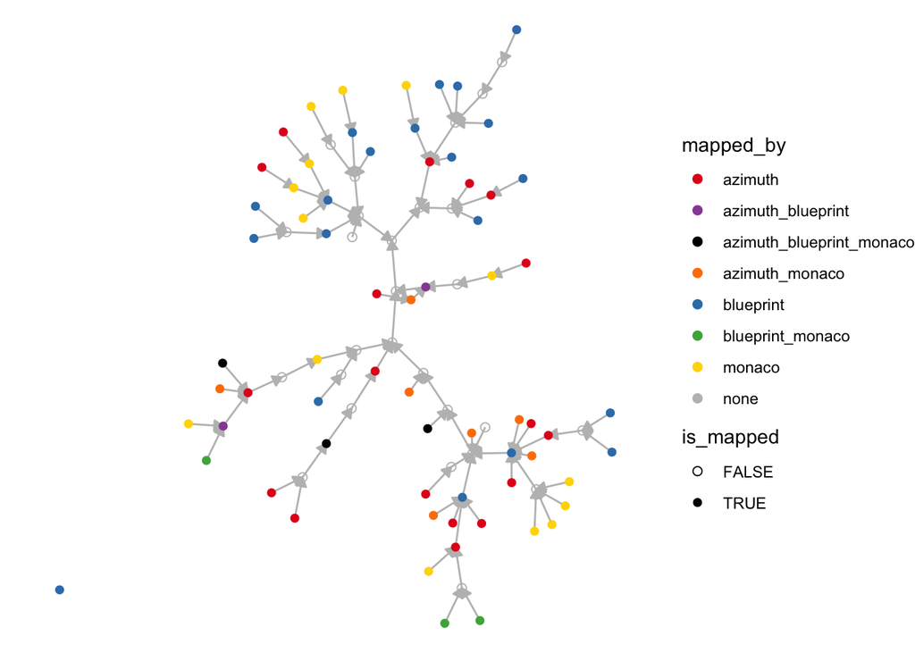

```r
# count child-parent for each vertex for validation
child_parent_count = do.call(
  rbind,
  lapply(minimal_vertices,
         function(x){
           data.frame(node=x,
                      num_parent=degree(hcao.simplified.dag,x,mode = "out"),
                      num_child =degree(hcao.simplified.dag,x,mode = "in"))
         }))

# check mapped vertices by the 3 references
V(hcao.simplified.dag)$azimuth_mapped = V(hcao.simplified.dag)$name %in% azimuth_label_fine_to_ont$to
V(hcao.simplified.dag)$blueprint_mapped = V(hcao.simplified.dag)$name %in% blueprint_label_fine_to_ont$to
V(hcao.simplified.dag)$monaco_mapped = V(hcao.simplified.dag)$name %in% monaco_label_fine_to_ont$to
V(hcao.simplified.dag)$mapped_by = mapply(
  FUN=function(...){
    txt = paste0(c("azimuth","blueprint","monaco")[c(...)],collapse="_")
    if(nchar(txt)<=0) txt = "none"
    return(txt)
  },
  V(hcao.simplified.dag)$azimuth_mapped,V(hcao.simplified.dag)$blueprint_mapped,V(hcao.simplified.dag)$monaco_mapped)
V(hcao.simplified.dag)$is_mapped = mapply(
  any,
  V(hcao.simplified.dag)$azimuth_mapped,V(hcao.simplified.dag)$blueprint_mapped,V(hcao.simplified.dag)$monaco_mapped)

# add common name label as attribute
V(hcao.simplified.dag)$label = unique_cl_labels[V(hcao.simplified.dag)$name]
V(hcao.simplified.dag)$label[is.na(V(hcao.simplified.dag)$label)] = "non immune"

# visual check
hcao.simp.dag.plot = ggraph(hcao.simplified.dag,layout = "kk")+
  geom_edge_link(arrow = arrow(length = unit(2, 'mm'),type = "closed"),color="grey") +
  geom_node_point(mapping = aes(color=mapped_by,shape=is_mapped),size=2) +
  #geom_node_text(mapping=aes(label=label,color=mapped_by),nudge_y = 0.1)+
  scale_color_manual(values = mapped_color)+
  scale_shape_manual(values = mapped_shape)+
  scale_x_continuous(expand = c(0.1,0.1))+
  theme_void()
print(hcao.simp.dag.plot)
```

## Mapping levels from heuristic immune graph

We reverse the direction of edges for compatibility with the heuristic immune graph.

```r
HCAO_graph = reverse_edges(hcao.simplified.dag)
```

We then read the heuristic immune graph and label each node by its level.

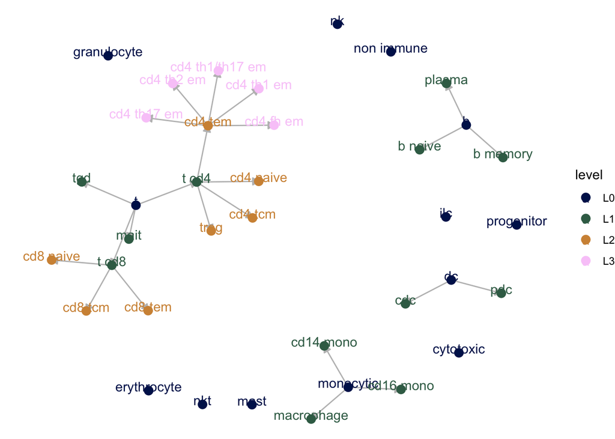

```r
# load knowledge graph
adj_immune = read.csv("graphs/immune_tree.csv", row.names = 1, check.names = FALSE) |>
  as.matrix()
immune_graph = graph_from_adjacency_matrix(adj_immune, mode = "directed", weighted = TRUE)

# Hierarchy - true (known) hierarchical relationships
# Consensus-only - temporary relationship used for ambiguous or often confused classes (e.g. macrophages and monocytes are often considered a single class but macrophages are not monocytes)
E(immune_graph)$Type = ifelse(E(immune_graph)$weight == 1, "Hierarchy", "Consensus-only")
E(immune_graph)$weight = 1

# Manually curate the graph based on the manuscript
curated_immune_graph = delete_edges(immune_graph,incident(immune_graph, "cytotoxic", mode="out"))

#
immune_graph_to_root = lapply(V(curated_immune_graph)$name,function(nn){
  as_ids(ego(graph = curated_immune_graph,order = -1,nodes = nn,mode = "in")[[1]])
})

#
immune_graph_strata = data.frame(
  label=sapply(immune_graph_to_root,function(x){x[1]}),
  level=paste0("L",sapply(immune_graph_to_root,length)-1))

# Add level to vertex metadata
V(immune_graph)$level = immune_graph_strata$level[match(V(immune_graph)$name,immune_graph_strata$label)]
V(curated_immune_graph)$level = immune_graph_strata$level[match(V(curated_immune_graph)$name,immune_graph_strata$label)]

#
immune_graph_edges = igraph::as_data_frame(immune_graph,what="edges")
immune_graph_vertices = igraph::as_data_frame(immune_graph,what="vertices")

curated_immune_graph_edges = igraph::as_data_frame(curated_immune_graph,what="edges")
curated_immune_graph_vertices = igraph::as_data_frame(curated_immune_graph,what="vertices")

# Immune graph level color scheme
immune_level_color = c(
  L0 = "#001959",
  L1 = "#3B6C55",
  L2 = "#D29243",
  L3 = "#F9CCF9"
)

ggraph(curated_immune_graph,layout = "kk")+
  geom_edge_link(arrow = arrow(length = unit(2, 'mm'),type = "closed"),color="grey") +
  geom_node_point(mapping = aes(color=level),size=3) +
  geom_node_text(mapping=aes(label=name,color=level),nudge_y = 0.1)+
  scale_color_manual(values = immune_level_color)+
  scale_x_continuous(expand = c(0.1,0.1))+
  theme_void()
```

The mapping of heuristic immune graph level is manually done, with the exclusion of cytotoxic and natural killer T cell.

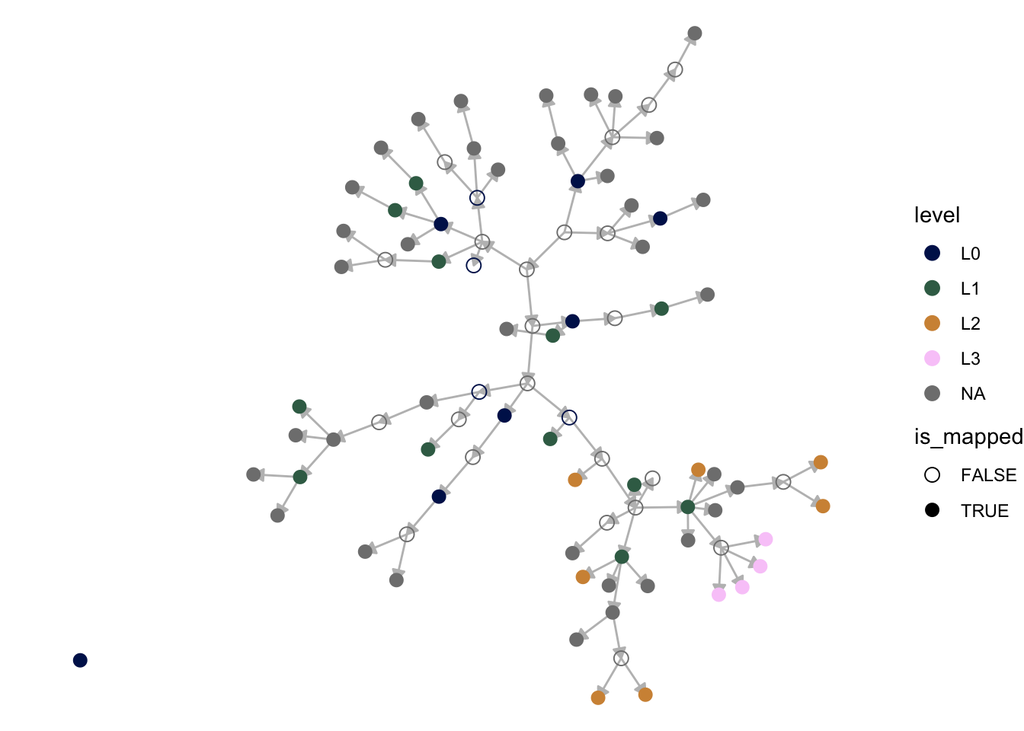

```r
# Manual mapping of immune graph levels to HCAO immune graph
## cytotoxic and nkt were removed based on manual curation
immune_graph_to_HCAO_graph = c(
  "b" = "CL_0000945",
  "b memory" = "CL_0000787",
  "b naive" = "CL_0000788",
  "plasma" = "CL_0000786",
  "ilc" = "CL_0001065",
  "nk" = "CL_0000623",
  "t" = "CL_0000084",
  "t cd4" = "CL_0000624",
  "cd4 naive" = "CL_0000895",
  "cd4 tcm" = "CL_0000904",
  "cd4 tem" = "CL_0000905",
  "cd4 fh em"="CL_0002038",
  "cd4 th1/th17 em"="CL_0000912",
  "cd4 th1 em" = "CL_0000545",
  "cd4 th2 em" = "CL_0000546",
  "cd4 th17 em" = "CL_0000899",
  "t cd8" = "CL_0000625",
  "cd8 naive" = "CL_0000900",
  "cd8 tcm" = "CL_0000907",
  "cd8 tem" = "CL_0000913",
  "tgd" = "CL_0000798",
  "treg" = "CL_0000815",
  "mait" = "CL_0000940",
  "erythrocyte" = "CL_0000764",
  "granulocyte" = "CL_0000094",
  "monocytic" = "CL_0000576",
  "cd14 mono" = "CL_0000860",
  "cd16 mono" = "CL_0000875",
  "dc" = "CL_0000451",
  "cdc" = "CL_0000782",
  "pdc" = "CL_0000784",
  "macrophage" = "CL_0000235",
  "mast" = "CL_0000097",
  "progenitor" = "CL_0008001",
  "non immune" = "not hematopoietic"
)

# Add mapped level to the HCAO immune graph
HCAO_graph_strata = data.frame(
  label=unname(immune_graph_to_HCAO_graph[immune_graph_strata$label]),
  level=immune_graph_strata$level
  )
HCAO_graph_strata = HCAO_graph_strata[!is.na(HCAO_graph_strata$label),]
V(HCAO_graph)$level = HCAO_graph_strata$level[
  match(V(HCAO_graph)$name,HCAO_graph_strata$label)
]
V(HCAO_graph)$n_level = as.numeric(gsub("\\D+", "", V(HCAO_graph)$level))

# Visualize to check
mapped_shape = c("TRUE"=16,"FALSE"=1)
ggraph(HCAO_graph,layout = "kk")+
  geom_edge_link(arrow = arrow(length = unit(2, 'mm'),type = "closed"),color="grey") +
  geom_node_point(mapping = aes(color=level,shape=is_mapped),size=3) +
  #geom_node_text(mapping=aes(label=label,color=level),nudge_y = 0.1)+
  scale_color_manual(values = immune_level_color)+
  scale_shape_manual(values = mapped_shape)+
  scale_x_continuous(expand = c(0.1,0.1))+
  theme_void()
```

Now we fill-in the gap between mapped levels in HCAO graph.

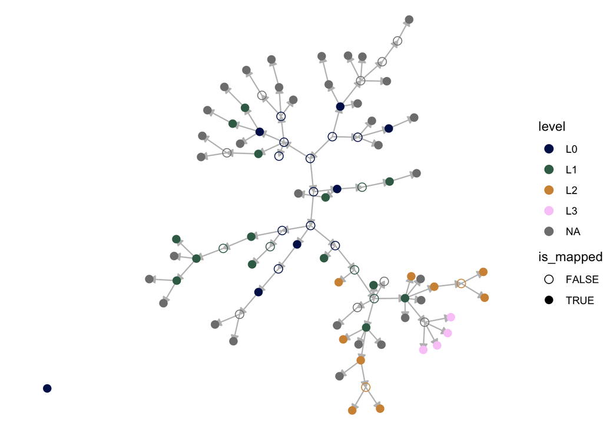

```r
# prepare to hierarchically fill-in level for vertices that are not mapped
all_path_to_root = lapply(V(HCAO_graph)$name,function(x){
  lapply(ego(HCAO_graph,order = -1,mode = "in",nodes = x),as_ids)
})
names(all_path_to_root) = V(HCAO_graph)$name

all_children_by_node = lapply(V(HCAO_graph)$name,function(x){
  V(HCAO_graph)$name[sapply(all_path_to_root,function(xx){
    any(sapply(xx,function(xxx){x%in%xxx}))
  })]
})
names(all_children_by_node) = V(HCAO_graph)$name

all_sisters_by_node = lapply(V(HCAO_graph)$name,function(x){
  setdiff(lapply(ego(HCAO_graph,order = 1,mode = "out",nodes = x),as_ids)[[1]],x)
})
names(all_sisters_by_node) = V(HCAO_graph)$name


# fill-in parental vertices (0>1>2)
for(this_level in 0:2){
  level_mapping=V(HCAO_graph)$n_level
  names(level_mapping) = V(HCAO_graph)$name
  vertices_with_level = V(HCAO_graph)$name[which(V(HCAO_graph)$n_level==this_level)]
  parent_until_higher_level = unique(do.call(c,lapply(
    vertices_with_level,
    function(x){
      vv = all_path_to_root[[x]][[1]]
      v2f = vv[which(is.na(level_mapping[vv]))]
      return(v2f)
    }
  )))
  level_mapping[parent_until_higher_level] = this_level
  V(HCAO_graph)$n_level = unname(level_mapping)
}
V(HCAO_graph)$level = sapply(V(HCAO_graph)$n_level,function(x){
  if(is.na(x)) return(NA)
  return(paste0("L",x))
})

# Visualize to check again
ggraph(HCAO_graph,layout = "kk")+
  geom_edge_link(arrow = arrow(length = unit(2, 'mm'),type = "closed"),color="grey") +
  geom_node_point(mapping = aes(color=level,shape=is_mapped),size=3) +
  #geom_node_text(mapping=aes(label=label,color=level),nudge_y = 0.1)+
  scale_color_manual(values = immune_level_color)+
  scale_shape_manual(values = mapped_shape)+
  scale_x_continuous(expand = c(0.1,0.1))+
  theme_void()
```

The remaining unmapped vertices are addressed by their latest mapped ancestors.

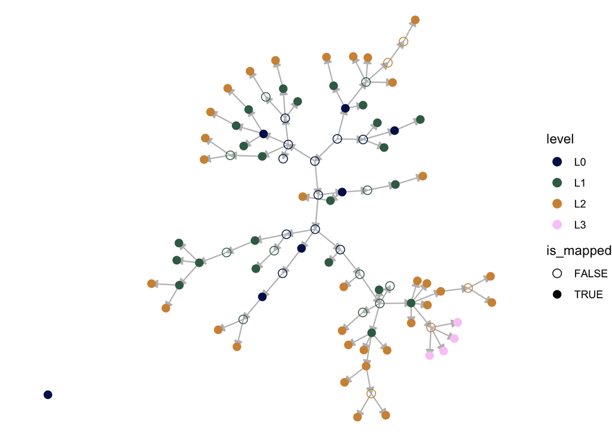

```r
# now fill-in vertices not mapped and without mapped descendents at level 0-2
vertices_to_fill = V(HCAO_graph)$name[is.na(V(HCAO_graph)$n_level)]
#print(length(vertices_to_fill))
while(length(vertices_to_fill)>0){
  for(this_vertex in vertices_to_fill){
    immediate_parent = all_path_to_root[[this_vertex]][[1]][2]
    # skip if parent not mapped
    if(immediate_parent%in%vertices_to_fill) next
    # prioritize for L0 parent to produce L1 children
    if(level_mapping[immediate_parent]<=0){
      level_mapping[this_vertex] = 1
      next
    }
    # if has mapped sister, use sisters' finest level
    if(length(all_sisters_by_node[[immediate_parent]])>1){
      # ^check if has sister
      # check if any sister is mapped
      sister_level = level_mapping[all_sisters_by_node[[immediate_parent]]]
      sister_level = sister_level[!is.na(sister_level)]
      # use finest level when mapped
      if(length(sister_level)>0){
        level_mapping[this_vertex] = max(sister_level)
        next
      }
      # fill-in as single child when not mapped
    }
    # +1 if itself is mapped to a reference and +0 if not
    if(V(HCAO_graph)$is_mapped[V(HCAO_graph)$name==this_vertex]){
      level_mapping[this_vertex] = min(level_mapping[immediate_parent]+1,2)
      # limit the extrapolation of level to 2 based on manual curation
    }else{
      level_mapping[this_vertex] = level_mapping[immediate_parent]
    }
  }
  V(HCAO_graph)$n_level = unname(level_mapping)
  vertices_to_fill = V(HCAO_graph)$name[is.na(V(HCAO_graph)$n_level)]
  #print(length(vertices_to_fill))
}

V(HCAO_graph)$level = sapply(V(HCAO_graph)$n_level,function(x){
  if(is.na(x)) return(NA)
  return(paste0("L",x))
})

# Visualize to check again
ggraph(HCAO_graph,layout = "kk")+
  geom_edge_link(arrow = arrow(length = unit(2, 'mm'),type = "closed"),color="grey") +
  geom_node_point(mapping = aes(color=level,shape=is_mapped),size=3) +
  #geom_node_text(mapping=aes(label=label,color=level),nudge_y = 0.1)+
  scale_color_manual(values = immune_level_color)+
  scale_shape_manual(values = mapped_shape)+
  scale_x_continuous(expand = c(0.1,0.1))+
  theme_void()
```

We save the final HCAO graph for use in cellNexus pipeline.

```r
HCAO_vertices= igraph::as_data_frame(HCAO_graph,what="vertices")
HCAO_edges= igraph::as_data_frame(HCAO_graph,what="edges")

write.table(HCAO_edges,file = "HCAO_immune_graph_edges.csv",
            quote = TRUE,sep = ",",row.names = FALSE,col.names = TRUE)
write.table(HCAO_vertices[,c("name","is_mapped","mapped_by","label","level")],
            file = "HCAO_immune_graph_vertices.csv",
            quote = TRUE,sep = ",",row.names = FALSE,col.names = TRUE)
```